# ANALYSIS OF INTEREST RATES (IR)

## Stationarity

### What is stationary time series?

A stationary process has a mean and variance that do not change overtime and the process does not have trend.

The above time series does not look stationary.

To confirm that we will use “Dickey-Fuller test” to determine stationarity.

Dickey-Fuller test for variable

```r
adf.test(rates$USD1MTD156N, alternative = "stationary")
```

```
    Augmented Dickey-Fuller Test

data:  rates$USD1MTD156N
Dickey-Fuller = -1.7887, Lag order = 20, p-value = 0.6679
alternative hypothesis: stationary
```

## Decomposing Time Series

Decomposing a time series means separating it into it’s constituent components, which are often a trend component and a random component, and if the data is seasonal, a seasonal component (for examaple holiday sales). For the interest rate data there seasonality would not be a important factor.

Decomposing non-Seasonal series consist of a trend component and a random component. Decomposing the time series involves tying to separate the time series into these individual components.

One way to do this is using some smoothing method, such as a simple moving average. The SMA() function in the TTR R package can be used to smooth time series data using a moving average. The SMA function takes a span argument as n order. To calculate the moving average of order 5, we set n = 5.

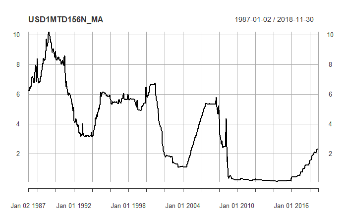

```r
USD1MTD156N_MA = SMA(rates$USD1MTD156N, n=10)
plot.xts(USD1MTD156N_MA)
```

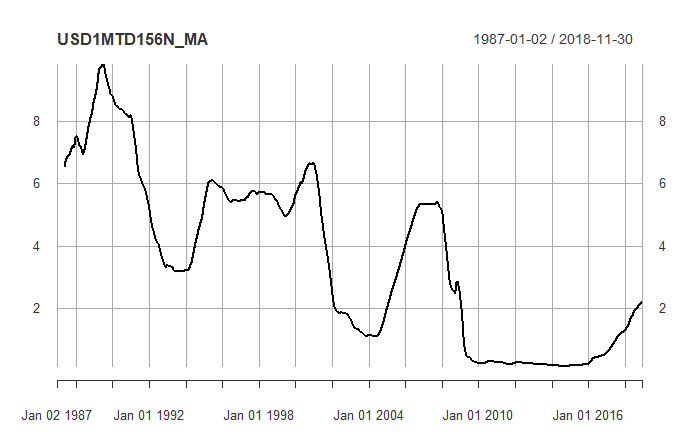

```r
USD1MTD156N_MA = SMA(rates$USD1MTD156N, n=100)
plot.xts(USD1MTD156N_MA)
```

This is better, we can see all the the hills and valleys.

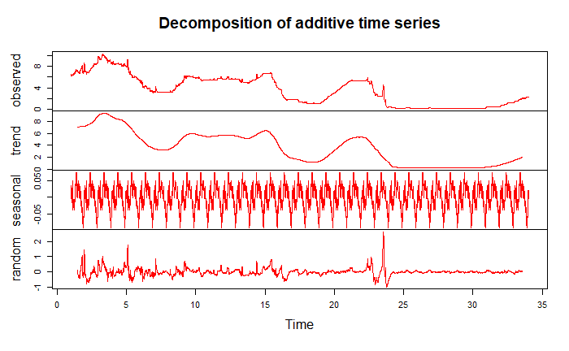

```r
USD1MTD156N_ts = ts(rates$USD1MTD156N, frequency = 12*(2008-1987))
USD1MTD156N_comp_add = decompose(USD1MTD156N_ts, type = 'additive')
plot(USD1MTD156N_comp_add, col = "red")
```